# [signal in the noise](http://localhost:1313)

Attempting to enter the loud conversation called 'Science'

# first

Fri, Jan 23, 2015

This is a test. Let’s see if it works.

# Background

My thesis is trying to get at the question: How does the genotype-phenotype map shape protein evolution? Specifically, how does this map shape accessible evolutionary trajectories through this space?

My purpose of looking at epistasis (including high order) is to build a microscopic, high-resolution picture of the genotype-phenotype map that we can refer to when analyzing the shape of trajectories through the map. Perhaps, we'll even be able to link key epistatic interactions to specific evolutionary trajectories.

# Question

What is the magnitude and structure of high-order epistasis in experimental genotype-phenotype maps? What are the implications of large epistasis on evolutionary outcomes?

# Regression Method

$l$ is the number of sites

$x_{s}$ is the state of site $s$, encoded as $0$s (wildtype) or $1$s (mutant).

$p(\{x\})$ is the fitness of sequence $\{x\}$

$k$'s are interaction parameters

$\alpha$ is the wild-type fitness

The algorithm is an ordinary least squares linear regression that fits the phenotype function to the data and yields values for the all $k$'s to a specified order of interaction. We can also propagate the experimental errors from the measured phenotype values through the regression and report confidence intervalues for all terms.

Our discoveries from computationally generated data:

1. **Underfitting** a higher-order epistatic genotype-phenotype map estimates the low order terms incorrect.
2. **Overfitting** the data correctly identifies the real interactions with **statistical significance**, while the overfit parameters are zero within statistical error.

```python
%matplotlib inline
import matplotlib.pyplot as plt
import numpy as np
from seqspace.geno_pheno_map.gpm_artificial import *
from seqspace.epistasis_map.regression import *

def correlation_plot(gpm, model, sigmas=0):
    learned_dict = model.get_interactions()
    known_dict = gpm.interaction_dict

    if len(learned_dict.keys()) < len(known_dict.keys()):
        interactions = learned_dict.keys()
    else:
        interactions = known_dict.keys()

    if sigmas == 0:
        learned = np.empty(len(interactions), dtype=float)
        known = np.empty(len(interactions), dtype=float)

        for i in range(len(interactions)):
            key = interactions[i]
            learned[i] = learned_dict[key]
            known[i] = known_dict[key]

        fig,ax = plt.subplots(1,1, figsize=[15,6])
        ax.plot(known,learned, '.')
    else:
        learned_dict = model.get_interactions()
        learned_error_dict = model.get_interaction_error()
        known_dict = egpm.interaction_dict

        interactions = known_dict.keys()
        learned = np.empty(len(interactions), dtype=float)
        known = np.empty(len(interactions), dtype=float)
        error = np.empty(len(interactions), dtype=float)

        for i in range(len(interactions)):
            key = interactions[i]
            learned[i] = learned_dict[key]
            known[i] = known_dict[key]
            error[i] = learned_error_dict[key]

        fig,ax = plt.subplots(1,1, figsize=[15,6])
        ax.plot(known,learned, '.')

        ax.errorbar(known,learned, yerr=3*error, fmt='.')

    ax.plot(np.linspace(min(known),max(known)),np.linspace(min(known),max(known)),'-r')
    ax.set_title("Correlation Plot", fontsize=20)
    ax.set_xlabel("Known",fontsize=20)
    ax.set_ylabel("Learned",fontsize=20)



def model_vs_real_plot(gpm, model, sigmas=0):
    fig, ax = model.plot_interaction_dataframe("Artificial Data",
                                           sigmas=sigmas)


    # Plot the real epistatic interactions on top of the regression terms.
    ordered = np.array(model.epistasis_dataframe["Interactions"])
    known_dict = egpm.interaction_dict
    known = np.zeros(len(ordered))
    for i in range(len(ordered)):
        if ordered[i] in known_dict:
            known[i] = known_dict[ordered[i]]

    ax.plot(known, 'g', label="Known")
    handles, labels = ax.get_legend_handles_labels()

    ax.legend(labels=["learned","known"])


def under_fit_plot(gpm, model, undermodel):
    fig, ax = model.plot_interaction_dataframe("Artificial Data",
                                           sigmas=0, color='g')

    ordered = np.array(model.epistasis_dataframe["Interactions"])
    under_dict = undermodel.get_interactions()
    under = np.zeros(len(ordered))
    for i in range(len(ordered)):
        if ordered[i] in under_dict:
            under[i] = under_dict[ordered[i]]


    ax.plot(under, 'b', label="learned")
    handles, labels = ax.get_legend_handles_labels()
    ax.legend(labels=["known","learned"])
```

# Regression’s performance on computationally generated data

Result:

1. **Fitting Works**! It recovers the correct epistasis on computationally generated data.
2. **Underfitting** a high-order space yields **incorrect estimates** for all terms.
3. Overfitting estimates low order terms correctly.
4. **Overfitting** estimates **all terms correctly within propagated error** estimates.

## Fitting recovers correct epistasis on computationally generated data.

Generate a 6-site, 3rd order epistasis genotype-phenotype map from the phenotype function and run the regression to check that we recover the epistasis.

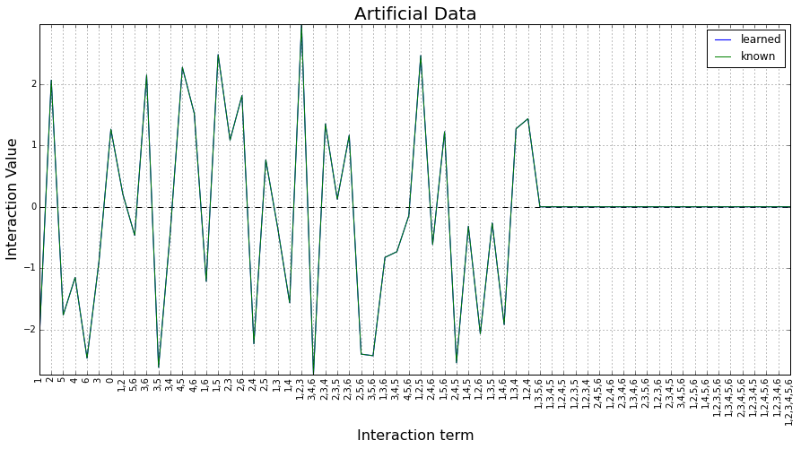

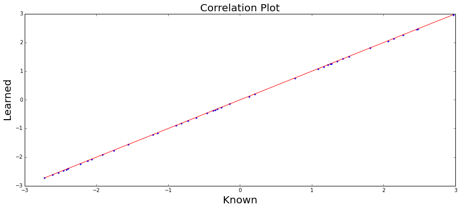

```python
length = 6       # sequence length
order = 3        # order of epistasis in system
magnitude = 3    # magnitude of epistasis
error = 0.05     # standard deviation (as percentage of phenotypes) simulation experimental error

# Build the artificial GPM
egpm = EpistasisGeneratedGPM(length,
                             order,
                             interaction_magnitude=magnitude,
                             error_percent=error)

fit_order = 6                                                 # What order should the regression fit to?

# Construct Epistasis Regression object
model = EpistasisRegression(egpm.sequences,
                            egpm.phenotypes,
                            interaction_order=fit_order,
                            log_phenotypes=False)             # no need to log-transform the artificial data.

model.fit()                                                   # fit the data
model.fit_error(egpm.std)
fig = model_vs_real_plot(egpm,model)
correlation_plot(egpm,model)
```

## Underfitting a high-order epistatic space yields incorrect estimates for epistatic terms

Run regression on the averaged values for each sampled phenotype with **2nd order function**.

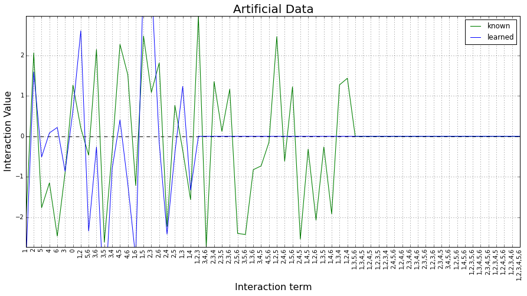

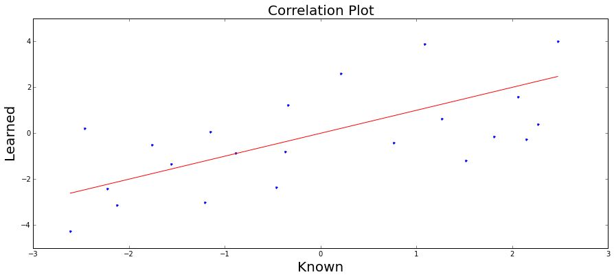

```python
fit_order = 2                                                 # What order should the regression fit to?

# Construct Epistasis Regression object
under_model = EpistasisRegression(egpm.sequences,
                            egpm.phenotypes,
                            interaction_order=fit_order,
                            log_phenotypes=False)             # no need to log-transform the artificial data.

under_model.fit()                                                   # fit the data
under_fit_plot(egpm,model,under_model)
correlation_plot(egpm,under_model)
```

## Overfitting with noisy data estimates lower order terms accurately.

1. Randomly sample from this map assuming normal distributions with 5% widths around each phenotype.
2. Run regression on the same averaged values for each sampled phenotype with **6th order function**.

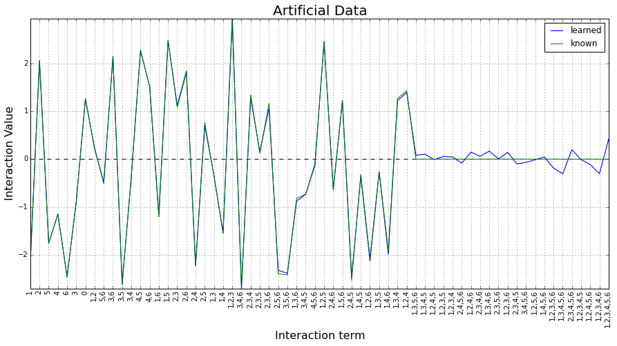

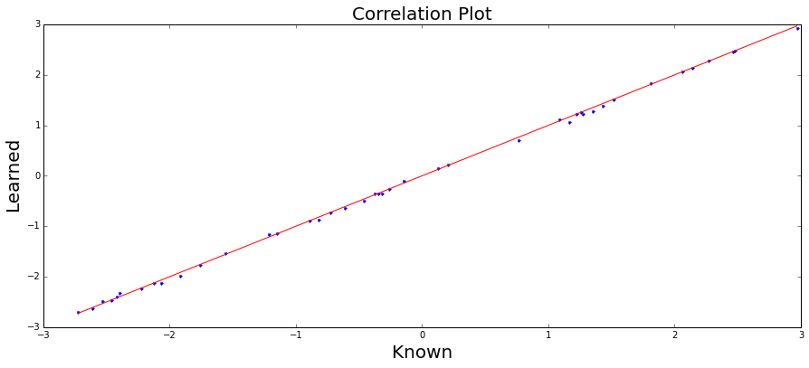

```python
# Sample of the phenotype distributions, simulation experimental measurements of the GPM
n = 30                                                # number of samples
g, p = egpm.create_samples(n)                         # array of samples for each phenotype

measured_genotypes = g[:,0]                           # genotypes
measured_phenotypes = np.mean(p,axis=1)               # mean of sampled phenotypes (simulating experimental measurements)
measured_std = np.std(p,axis=1)/np.sqrt(n)            # standard deviations of sampled phenotypes

fit_order = 6                                                 # What order should the regression fit to?

# Construct Epistasis Regression object
noisy_model = EpistasisRegression(measured_genotypes,
                            measured_phenotypes,
                            interaction_order=fit_order,
                            log_phenotypes=False)             # no need to log-transform the artificial data.

noisy_model.fit()                                                   # fit the data
noisy_model.fit_error(measured_std)
noisy_model.build_interaction_dataframe(include_error=True)
model_vs_real_plot(egpm,noisy_model)
correlation_plot(egpm,noisy_model)
```

**Problem**: How do we distinguish between meaningful and non-meaning terms in a model that overfits the data, specifically in the higher-order terms?

**Solution**: Propagate the experimental error and get confidence intervals for each interaction.

## Regression recovers epistasis in noisy data correctly within confidence intervals

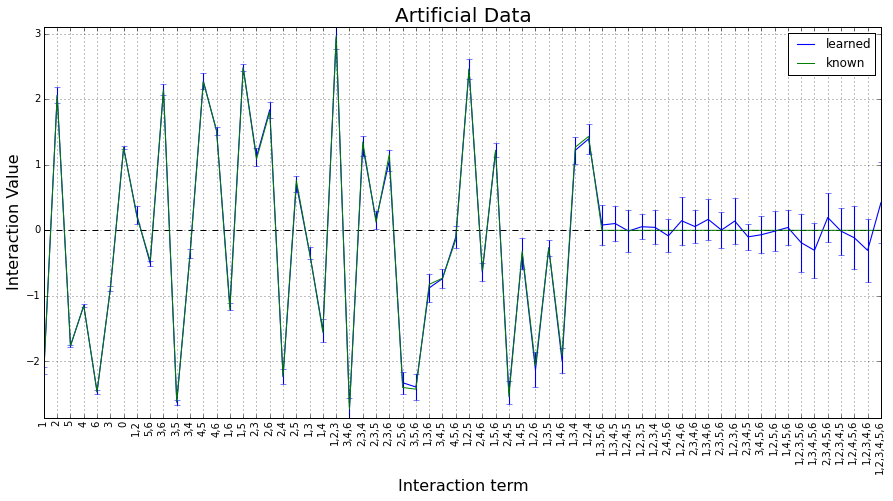

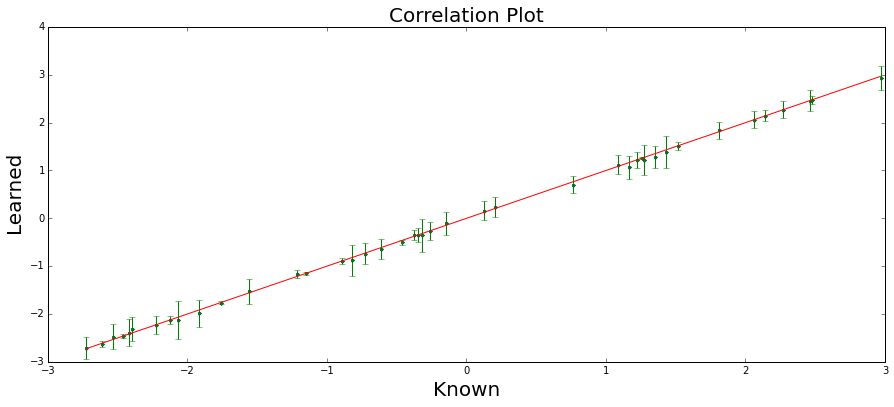

```python
model_vs_real_plot(egpm, noisy_model, sigmas=2)
correlation_plot(egpm, noisy_model, sigmas=2)
```